# Multiple Regression Model

강다현

2020 11 17

# 데이터 생성

다음과 같은 함수를 고려하자.
$$f(x) = \sin^3(2 \pi x^2),
\quad
x \in [0, 1].$$
위 함수를 이용해서 다음과 같은 선형회귀모형을 고려하자.
$$Y = f(x) + \varepsilon.$$
여기서 오차는 $\varepsilon \sim N(0, \sigma^2)$이며 이때 $\sigma = 0.1$이다. 위 회귀모형으로부터 $n = 200$개의 데이터를 생성해보자. 이때 $x$는 $[0, 1]$에서 등간격으로 생성한다.

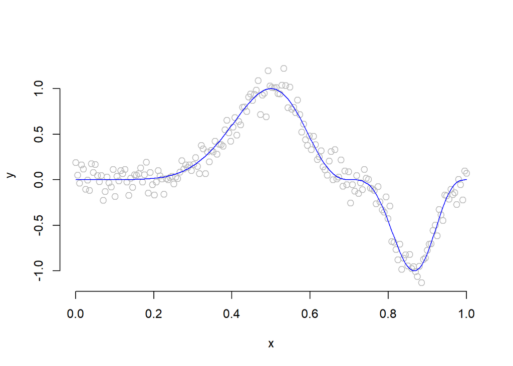

```r
rm(list = ls())
# seed 고정
set.seed(54)  # seed를 고정하지 않으면 같은 코드를 써도 항상 다른 결과가 나올 것이다.
# data generation
n = 200
x = seq(0, 1, length = n)
# true function
f = sin(2 * pi * x^2)^3
# response
sigma = 0.1  # 이렇게 변수를 생성해서 상수를 넣어주는 습관을 만들기로 하자 !
y = f + rnorm(n, sd = sigma)
# data plot
plot(x, y, col = "gray", cex = 1.2, bty = "n")
lines(x, f, col = "blue")
```

우리의 목표는 data만 주어졌을 때, 실제 회귀선을 추정하는 것이다. 이제 추정 과정을 전개해보자.

# 단순선형회귀모형 적합

```r
lm_fit = lm(y ~ x)
summary(lm_fit)
```

```
##
## Call:
## lm(formula = y ~ x)
##
## Residuals:
##     Min      1Q  Median      3Q     Max
## -0.9940 -0.2938 -0.0593  0.2816  1.1443
##
## Coefficients:
##             Estimate Std. Error t value Pr(>|t|)
## (Intercept)  0.39759    0.06616   6.009 8.80e-09 ***
## x           -0.60312    0.11445  -5.270 3.56e-07 ***
## ---
## Signif. codes:  0 '***' 0.001 '**' 0.01 '*' 0.05 '.' 0.1 ' ' 1
##
## Residual standard error: 0.4696 on 198 degrees of freedom
## Multiple R-squared:  0.123,  Adjusted R-squared:  0.1186
## F-statistic: 27.77 on 1 and 198 DF,  p-value: 3.556e-07
```

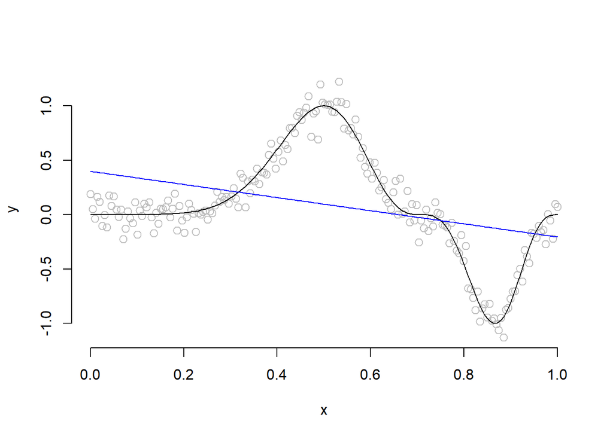

```r
plot(x, y, col = "gray", cex = 1.2, bty = "n")
lines(x, f)
lines(x, lm_fit$fitted.values, col = "blue")
```

보다시피, 직선만 가지고는 위 자료를 설명하는데 한계가 있다. 따라서, 이차항에 해당하는 $x^2$을 변수에 추가해서 이차시을 적합시켜보자.

## 이차항을 추가한 이차식 적합

```r
x2 = x^2
lm_fit2 = lm(y ~ x + x2)
summary(lm_fit2)
```

```
##
## Call:
## lm(formula = y ~ x + x2)
##
## Residuals:
##      Min       1Q   Median       3Q      Max
## -0.76545 -0.23910 -0.05725  0.23066  0.94616
##
## Coefficients:
##             Estimate Std. Error t value Pr(>|t|)
## (Intercept) -0.26756    0.07545  -3.546 0.000489 ***
## x            3.40799    0.34862   9.776  < 2e-16 ***
## x2          -4.01110    0.33744 -11.887  < 2e-16 ***
## ---
## Signif. codes:  0 '***' 0.001 '**' 0.01 '*' 0.05 '.' 0.1 ' ' 1
##
## Residual standard error: 0.3593 on 197 degrees of freedom
## Multiple R-squared:  0.4893, Adjusted R-squared:  0.4841
## F-statistic: 94.37 on 2 and 197 DF,  p-value: < 2.2e-16
```

```r
plot(x, y, col = "gray", cex = 1.2, bty = "n")
lines(x, f)
lines(x, lm_fit2$fitted.values, col = "blue")
```

[output not shown]

위의 코드를 보고 알 수 있는 점은 이차항을 추가해도 실제 회귀함수를 따라가는 데에는 무리가 있다.

## lm 함수의 다른 옵션 소개

2개 이상의 설명변수가 존재할 경우, 설명변수 데이터들을 행렬화해서 lm 함수에 적용할 수 있다.

```r
# 행렬만들기
X = cbind(x, x^2)  # 대문자 X를 회귀에서 '설계행렬'이라고 한다.
# 설계행렬을 이용해서 중회귀모형 적합
lm_fit2_matrix = lm(y ~ X)
summary(lm_fit2_matrix)
```

```
##
## Call:
## lm(formula = y ~ X)
##
## Residuals:
##      Min       1Q   Median       3Q      Max
## -0.76545 -0.23910 -0.05725  0.23066  0.94616
##
## Coefficients:
##             Estimate Std. Error t value Pr(>|t|)
## (Intercept) -0.26756    0.07545  -3.546 0.000489 ***
## Xx           3.40799    0.34862   9.776  < 2e-16 ***
## X           -4.01110    0.33744 -11.887  < 2e-16 ***
## ---
## Signif. codes:  0 '***' 0.001 '**' 0.01 '*' 0.05 '.' 0.1 ' ' 1
##
## Residual standard error: 0.3593 on 197 degrees of freedom
## Multiple R-squared:  0.4893, Adjusted R-squared:  0.4841
## F-statistic: 94.37 on 2 and 197 DF,  p-value: < 2.2e-16
```

```r
plot(x, y, col = "gray", cex = 1.2, bty = "n")
lines(x, f)
lines(x, lm_fit2_matrix$fitted.values, col = "blue")
```

[output not shown]

## 3차항 추가

```r
X = cbind(x, x^2, x^3)

lm_fit3 = lm(y ~ X)
summary(lm_fit3)
```

```
##
## Call:
## lm(formula = y ~ X)
##
## Residuals:
##      Min       1Q   Median       3Q      Max
## -0.73530 -0.23660 -0.05881  0.24990  0.83230
##
## Coefficients:
##             Estimate Std. Error t value Pr(>|t|)
## (Intercept) -0.38872    0.09911  -3.922 0.000121 ***
## Xx           4.88040    0.86049   5.672 5.02e-08 ***
## X           -7.70138    2.00240  -3.846 0.000162 ***
## X            2.46018    1.31609   1.869 0.063070 .
## ---
## Signif. codes:  0 '***' 0.001 '**' 0.01 '*' 0.05 '.' 0.1 ' ' 1
##
## Residual standard error: 0.357 on 196 degrees of freedom
## Multiple R-squared:  0.4982, Adjusted R-squared:  0.4906
## F-statistic: 64.87 on 3 and 196 DF,  p-value: < 2.2e-16
```

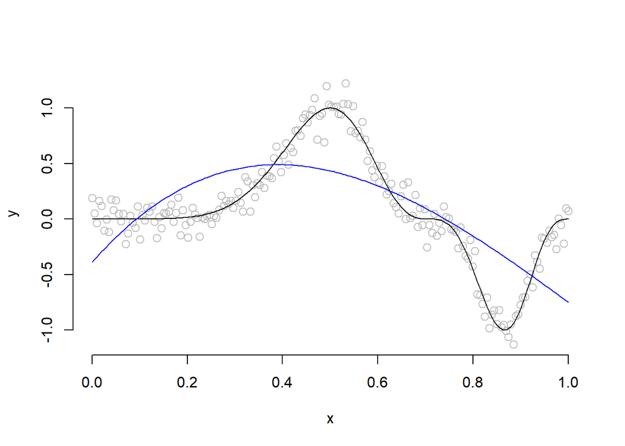

```r
plot(x, y, col = "gray", cex = 1.2, bty = "n")
lines(x, f)
lines(x, lm_fit3$fitted.values, col = "blue")
```

## 4차항 추가

```r
X = cbind(x, x^2, x^3, x^4)

lm_fit4 = lm(y ~ X)
summary(lm_fit4)
```

```
##
## Call:
## lm(formula = y ~ X)
##
## Residuals:
##      Min       1Q   Median       3Q      Max
## -0.45160 -0.15305 -0.00872  0.15431  0.50565
##
## Coefficients:
##               Estimate Std. Error t value Pr(>|t|)
## (Intercept)    0.45151    0.06794   6.645 2.95e-10 ***
## Xx           -12.31220    0.94645 -13.009  < 2e-16 ***
## X             70.11849    3.86275  18.152  < 2e-16 ***
## X           -118.79435    5.81071 -20.444  < 2e-16 ***
## X             60.62727    2.88235  21.034  < 2e-16 ***
## ---
## Signif. codes:  0 '***' 0.001 '**' 0.01 '*' 0.05 '.' 0.1 ' ' 1
##
## Residual standard error: 0.198 on 195 degrees of freedom
## Multiple R-squared:  0.8465, Adjusted R-squared:  0.8434
## F-statistic: 268.8 on 4 and 195 DF,  p-value: < 2.2e-16
```

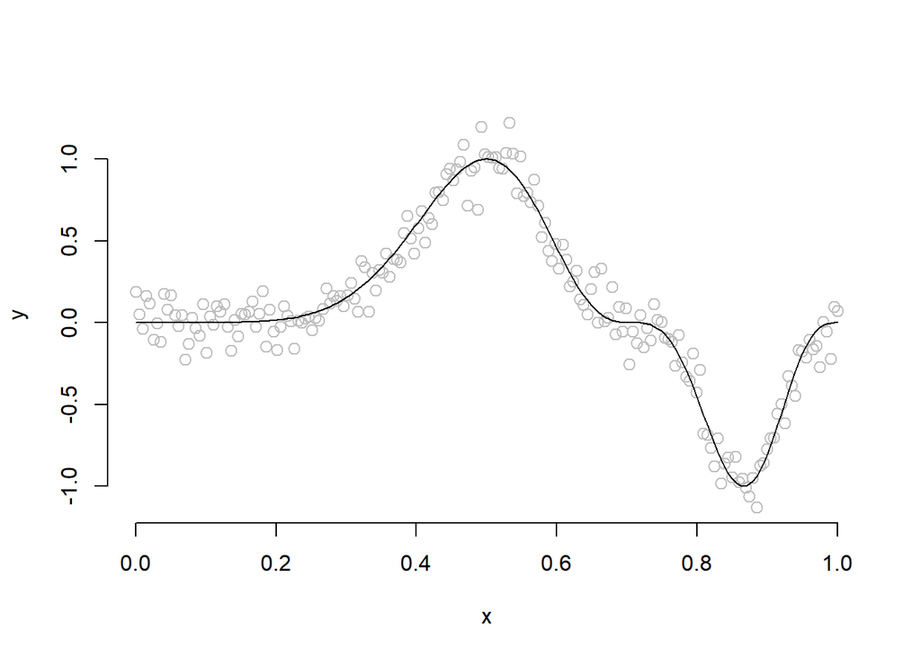

```r
plot(x, y, col = "gray", cex = 1.2, bty = "n")
lines(x, f)
```

## for 함수를 이용한 여러 다항회귀함수 적합

for 함수를 이용해서 1차부터 10차까지의 다항회귀함수를 적합해보고자 한다. 결과는 그림으로만 확인하자.

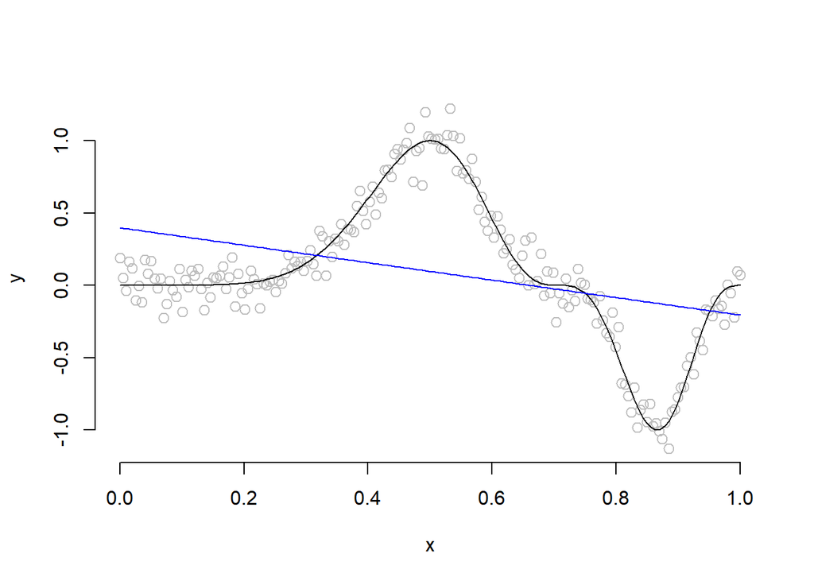

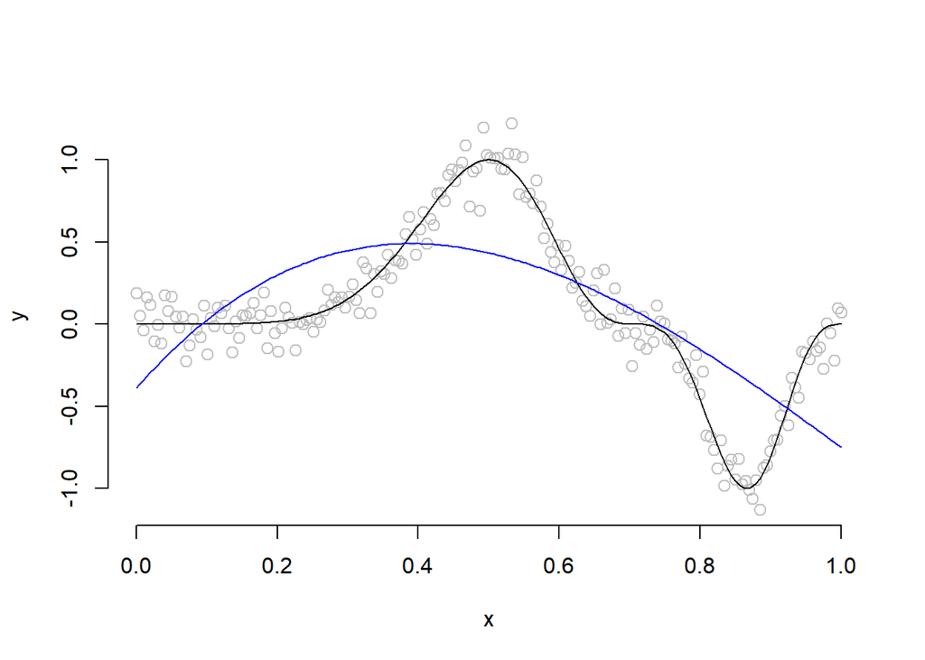

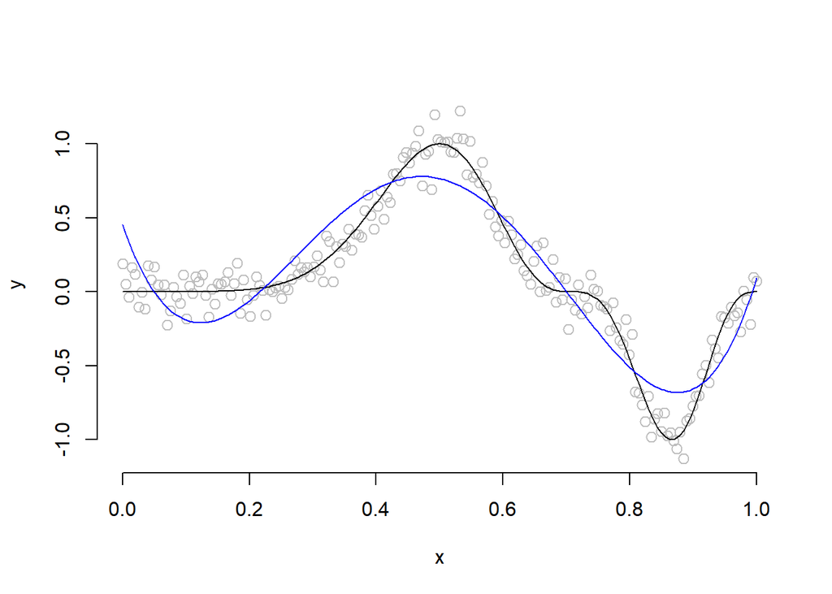

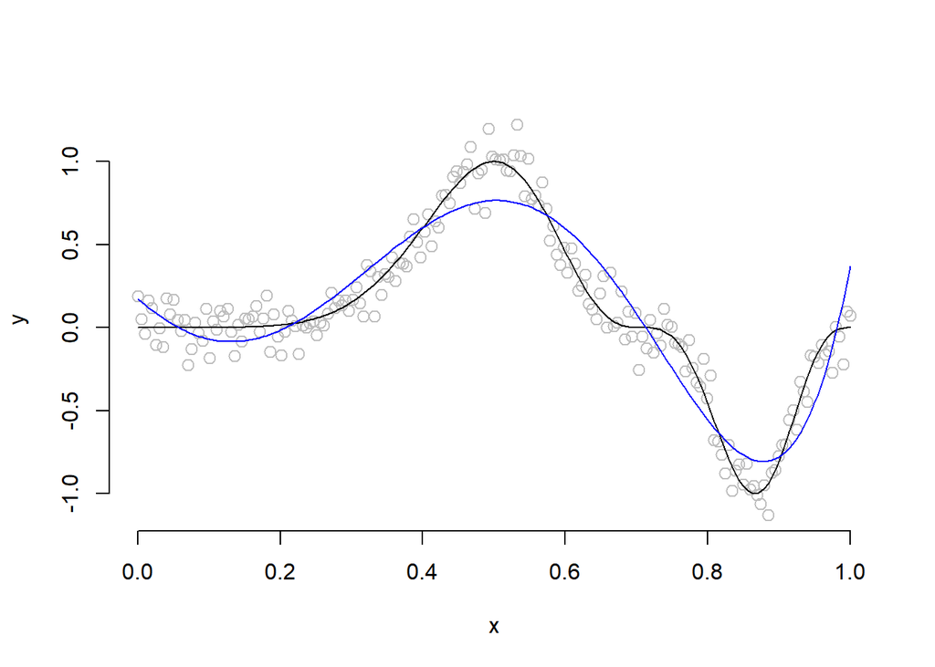

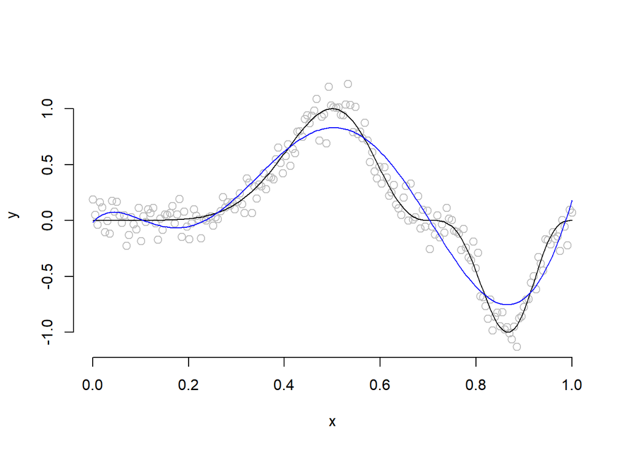

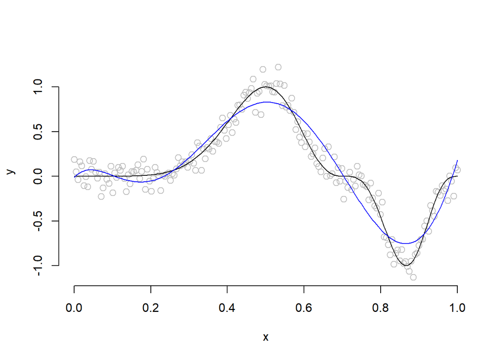

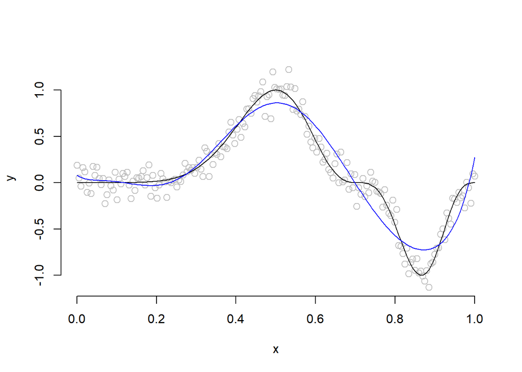

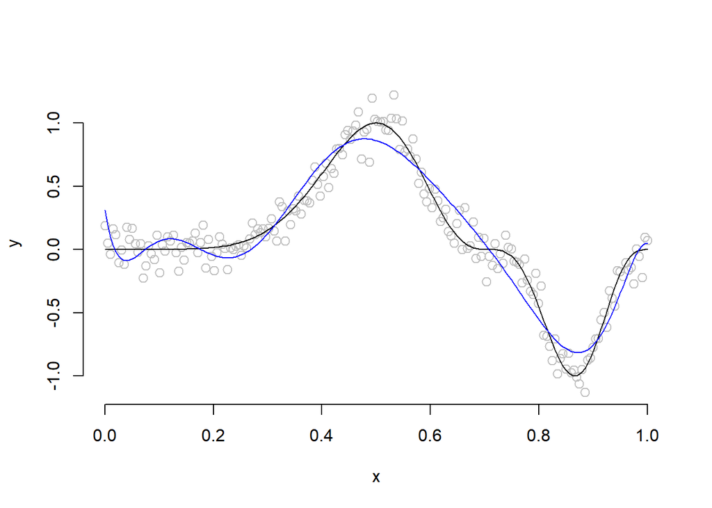

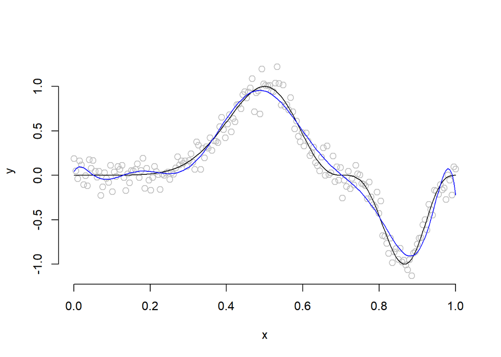

```r
X = NULL  # 빈 변수 생성
for (i in 1:10)
{
   X = cbind(X, x^i)  # 이 for문 안의 핵심은 설계행렬이다.
   lm_fit = lm(y ~ X)
   plot(x, y, col = "gray", cex = 1.2, bty = "n")
   lines(x, f)
   lines(x, lm_fit$fitted.values, col = "blue")
}
```

[output not shown]

## 문서 정리

바로 위의 for문을 이용한 함수를 조금 더 가다듬어서 문서정리를 해보자.

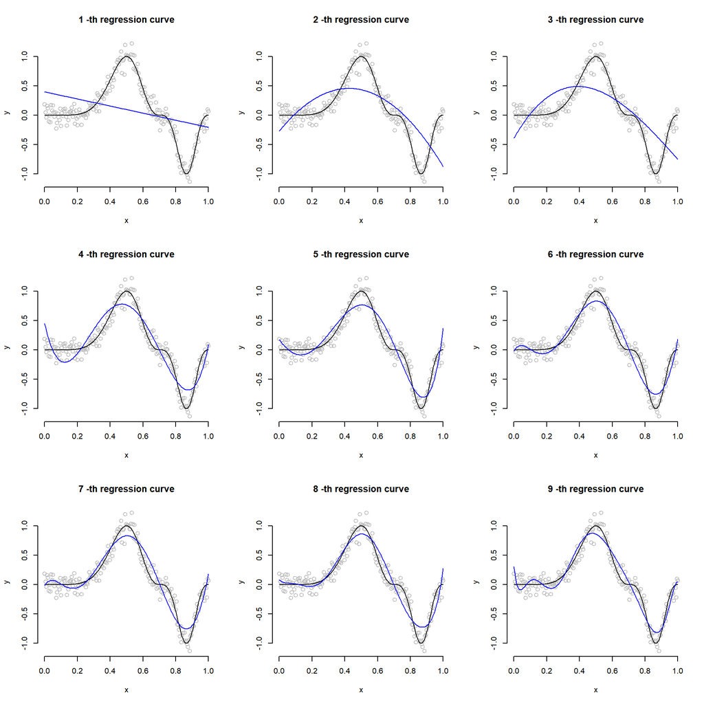

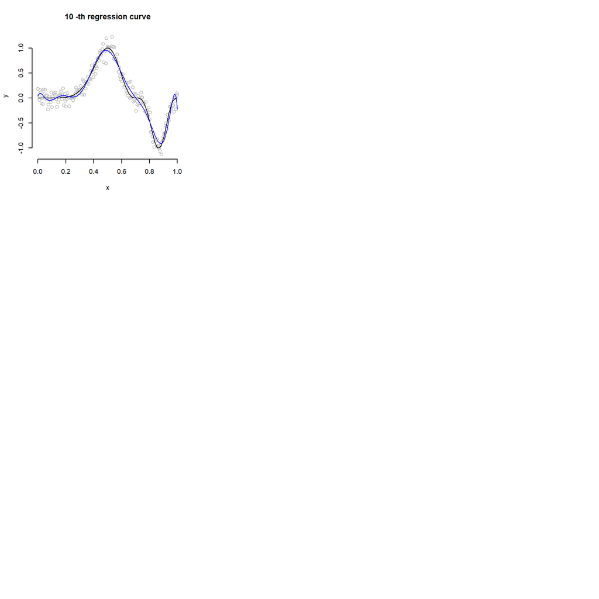

```r
# 그림 행렬 분할
# 그림을 그릴 때, 설정한 행렬 바둑판식으로 배열
# 그림은 행을 우선으로 채워넣음
par(mfrow = c(3, 3))
X = NULL  # 빈 변수 생성
for (i in 1:10)
{
   X = cbind(X, x^i)
   lm_fit = lm(y ~ X)
   plot(x, y, col = "gray", cex = 1.2, bty = "n",
        main = paste(i, "-th regression curve"))
   lines(x, f)
   lines(x, lm_fit$fitted.values, col = "blue")
}
```

## 여러 적합 결과들을 겹쳐서 확인하기

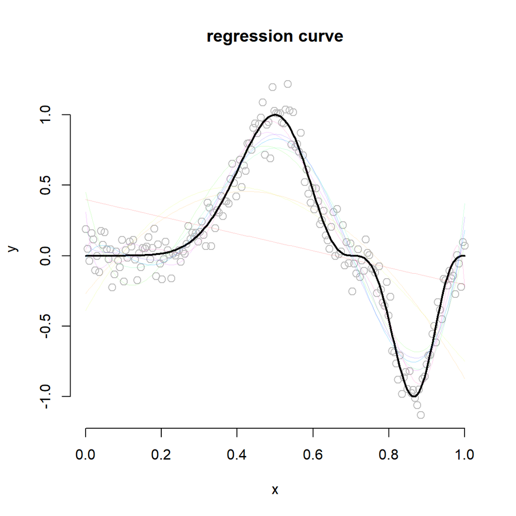

```r
X = NULL  # 빈 변수 생성
plot(x, y, col = "gray", cex = 1.2, bty = "n",
        main = paste("regression curve"))
lines(x, f, lwd = 2)  # 여러 회귀선이 겹치기 떄문에, 실제선의 굵기를 늘린다.(강조)
# rainbow 색깔 설정
# alpha = 색깔의 투명도
rain_color = rainbow(10, alpha = 0.2)
for (i in 1:10)
{
   X = cbind(X, x^i)  # 이 for문 안의 핵심은 설계행렬이다.
   lm_fit = lm(y ~ X)
   lines(x, lm_fit$fitted.values, col = rain_color[i],
         lwd = 0.5)  # 하나의 그림에 여러 개의 선을 넣을 때, 얇은 선을 사용하면 더 잘 보일 수 있다.
}
```

## 최적의 모형 선택

지금까지 해당 자료에 대해서 여러 가지 다항회귀함수를 적합(추정)해보았는데 , 이 중에서 자료를 가장 잘 설명하는 추정함수가 무엇일까?

summary를 했을 때, ‘Adjusted R-squared’ 라는 값이 결과에 나오는데, 이는 여러가지 모형을 적합시켰을 떄 가장 적합한 모형을 선택할 수 있는 기준이 된다.

```r
lm_fit = lm(y ~ x)
lm_fit_summary = summary(lm_fit)
lm_fit_summary$adj.r.squared
```

```
## [1] 0.1185657
```

summary로 요약된 정보를 이용해서 adj.r.squred 값을 저장할 수 있다. 이 저장된 값을 잘 이용하면 많은 정보를 얻을 수 있다.

## 예제

1. adjuted R-square (수정된 결정계수, $R^2_a$) 값을 근거로 하여 1-50차 추정함수 중 가장 $R^2_a$값이 큰 모형을 선택하는 알고리즘을 구현해보자.
2. 다음과 같이 $x$축을 최고차창 차원 (1:50), $y$축을 각 모형의 $R^2_a$값을 나타내는 그림을 그려보자.

```r
par(mfrow = c(1, 1))  # 행렬의 바둑판식의 틀 잡기
X = NULL  # 빈 변수 생성
adj_R = NULL # 빈 변수 생성(반복문을 거치면서 벡터로 변환됨)

for (i in 1:50)
{
   X = cbind(X, x^i)  # design matrix 생성
   lm_fit = lm(y ~ X)
   sum_lm_fit = summary(lm_fit)  # summary에 다양한 값이 리스트형태로 저장됨
   adj_R[i] = sum_lm_fit$adj.r.squared
}
adj_R
```

```
##  [1] 0.1185657 0.4841059 0.4905564 0.8433534 0.8764859 0.8897834 0.8892123
##  [8] 0.8918205 0.9091902 0.9336200 0.9333073 0.9481942 0.9481942 0.9562945
## [15] 0.9562945 0.9560812 0.9560812 0.9565723 0.9565723 0.9565290 0.9565290
## [22] 0.9565290 0.9568339 0.9568339 0.9568339 0.9567365 0.9567365 0.9567365
## [29] 0.9567365 0.9565077 0.9565077 0.9565077 0.9565077 0.9562652 0.9562652
## [36] 0.9562652 0.9562652 0.9562652 0.9562929 0.9562929 0.9562929 0.9562929
## [43] 0.9562929 0.9562929 0.9560472 0.9560472 0.9560472 0.9560472 0.9560472
## [50] 0.9560472
```

```r
# max : 최대 값을 반환
max(adj_R)
```

```
## [1] 0.9568339
```

```r
# which.max : 최대 값이 있는 위치 반환
which.max(adj_R)
```

```
## [1] 23
```

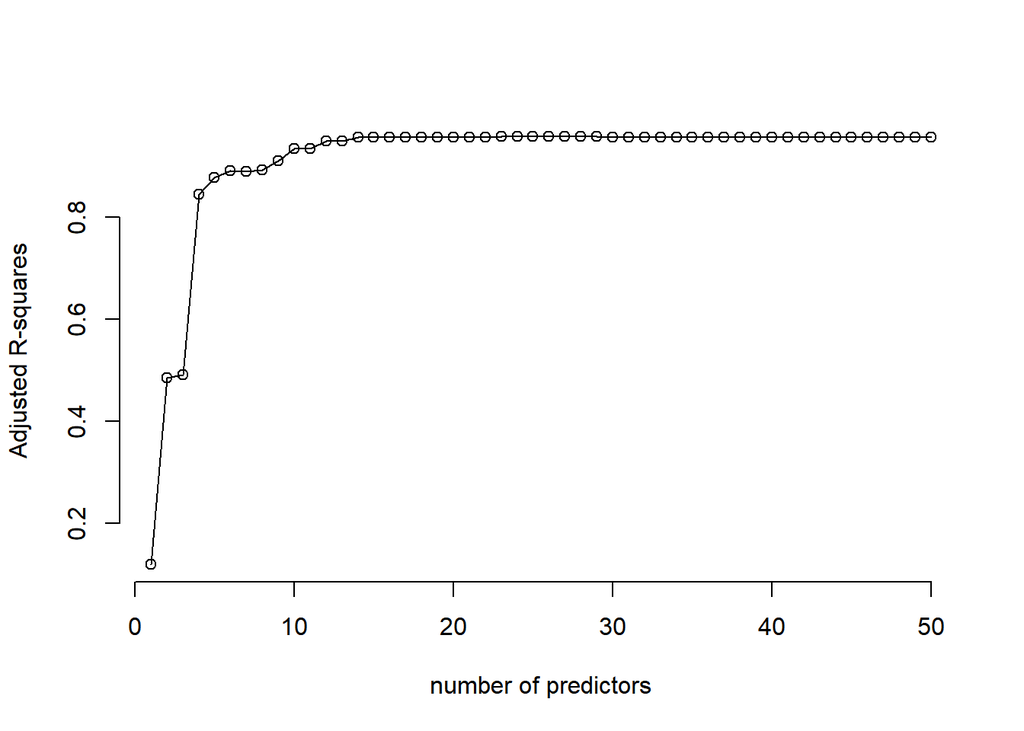

```r
plot(1:50, adj_R, type = "o", bty = "n",
     xlab = "number of predictors", ylab = "Adjusted R-squares")
```

- 가장 큰 $R^2_a$에 해당하는 위치(index)를 which.max 함수를 적절히 이용해서 찾고, 다음과 같은 메세지를 cat 함수를 이용해서 출력해볼 것

```r
index = which.max(adj_R)
cat(c("Adjusted R-squre 값이 가장 큰 모형은 =", index,  "번째 모형이다."))
```

```
## Adjusted R-squre 값이 가장 큰 모형은 = 23 번째 모형이다.
```

- 그림의 효과를 극대화 하기 위해서, 앞의 1-14번째 모형은 제외하고, 15번째 모형부터 50번째 모형에 대한 $R^2_a$ 값만 그려볼 것.
- 앞에서 얻은 최적의 모형에 해당하는 위치를 아래와 같이 강조하여 표현해 볼 것.

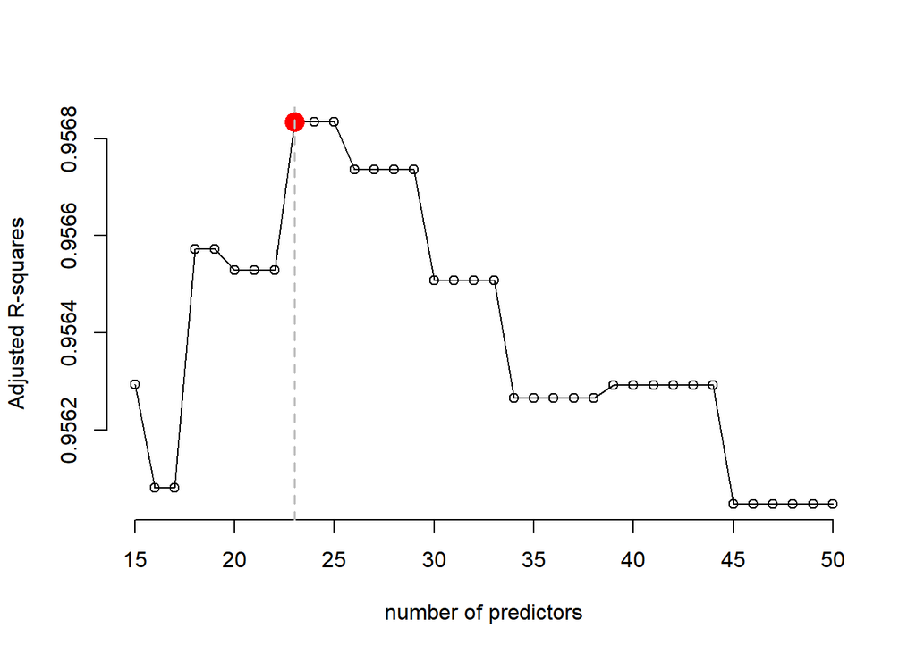

```r
plot(15:50, adj_R[15:50], type = "o", bty = "n",
     xlab = "number of predictors", ylab = "Adjusted R-squares")
points(index, adj_R[index], col = "red", pch = 16, cex = 2)
abline(v = index, col = "gray", lwd = 1.5, lty = 2)  # 수직선을 그어주는 함수
```

### 최종으로 선택된 모형만 다시 적합시켜 시각화해볼 것.

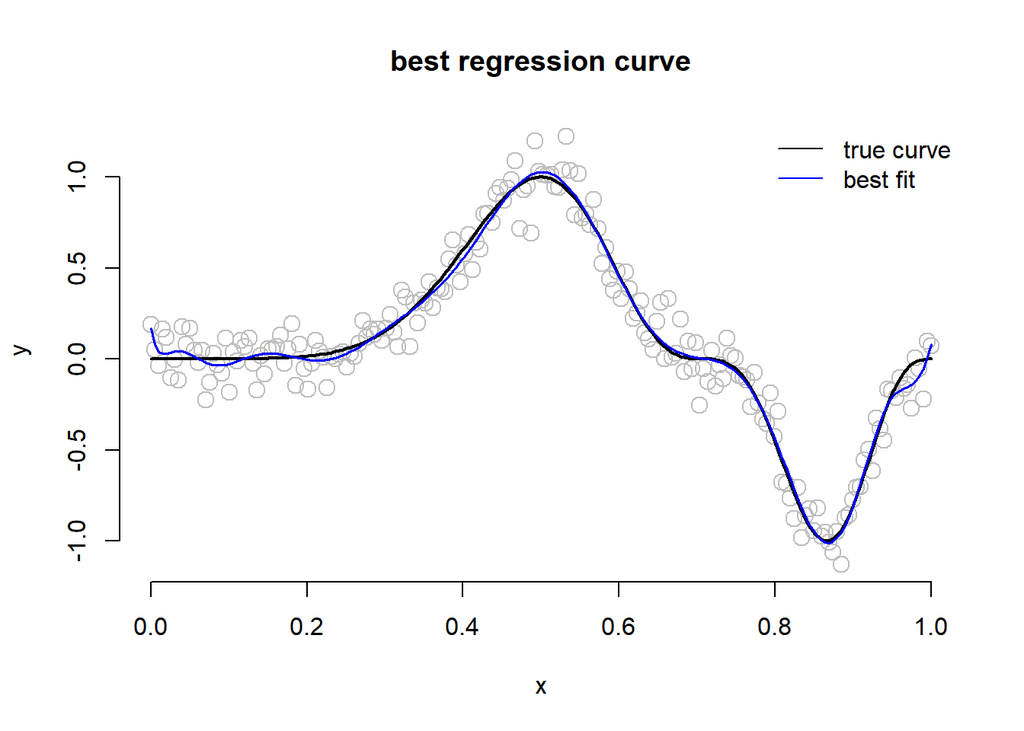

```r
X = NULL
for(i in 1:index)
   X = cbind(X, x^i)
lm_fit = lm(y ~ X)
plot(x, y, col = "gray", cex = 1.5, bty = "n",
     main = paste("best regression curve"))
lines(x, f, lwd = 2)
lines(x, lm_fit$fitted.values, col = "blue", lwd = 1.5)
legend("topright", legend = c("true curve", "best fit"),
       col = c("black", "blue"), lwd = 1, lty = 1, bty = "n")
```